# Modelos en biología — Tarea 2

Hernando Diaz

2023/05/10

### Cada grupo debe responder las tres preguntas. El resultado debe ser un documento *R-markdown*. Use este archivo como base para su tarea.

## 1. Modelo de Lotka Volterra

Considere el modelo
$$\begin{align}
\frac{d x_1(t)}{dt}=
&r_1x_1\left[1-\frac{x_1(t)+\alpha_{12}x_2(t)}{K_1}\right]\\
\frac{d x_2(t)}{dt}=
&r_2x_2\left[1-\frac{x_2(t)+\alpha_{21}x_1(t)}{K_2}\right]
\end{align}$$
donde $x_1$ y $x_2$ representan dos poblaciones que comparten un ecosistema. Las variables $x_1$ y $x_2$ pueden representar los tamaños de las dos poblaciones en términos absolutos.

El modelo representado por las ecuaciones anteriores se denomina modelo de Volterra-Lotka y representa muchas relaciones posibles, según sean los signos de $\alpha_{12}$ y $\alpha_{21}$, como se muestra a continuación:

| $\alpha_{12}$ | $\alpha_{21}$ | Tipo de relación |
| --- | --- | --- |
| $-$ | $-$ | Mutualismo |
| $-$ | $0$ | Comensal |
| $0$ | $-$ | Comensal |
| $+$ | $-$ | Parasitismo |
| $-$ | $+$ | Parasitismo |
| $+$ | $+$ | Competencia |

Cada grupo debe seleccionar dos de estos casos, escoger unos valores razonables de los parámetros y responder las preguntas a continuación para cada uno de estos casos.

### Implementación del modelo Lotka-Volterra:

```r
library(deSolve)
library(ggplot2)

# Lotka-Volterra
simulate_LV <- function(r1, r2, a12, a21, K1, K2, x1, x2, tmax) {
  params <- c(r1=r1, r2=r2, a12=a12, a21=a21, K1=K1, K2=K2)
  state <- c(x1=x1, x2=x2)

  LV <- function(t, state, params) {
    with(as.list(c(state, params)), {
      dx1 = r1 * x1 * (1 - ((x1 + a12 * x2) / K1))
      dx2 = r2 * x2 * (1 - ((x2 + a21 * x1) / K2))
      list(c(dx1, dx2))
    })
  }

  times <- seq(0, tmax, by=0.01)

  out <- as.data.frame(ode(y = state, times=times, func=LV, parms=params))

  ggplot(out, aes(x = time)) +
    geom_line(aes(y = x1, color = "x1")) +
    geom_line(aes(y = x2, color = "x2")) +
    xlab("Time") +
    ylab("Population Size") +
    scale_color_manual(values = c("x1" = "blue", "x2" = "red"))

}
```

### Ejemplos: Mutualismo y Competencia:

#### Mutualismo

```r
simulate_LV(r1 = 1.0, r2 = 0.3,
            a12 = -0.2, a21 = -0.2,
            K1 = 100, K2 = 120,
            x1 = 50, x2 = 10,
            tmax = 200)
```

[output not shown]

#### Competencia

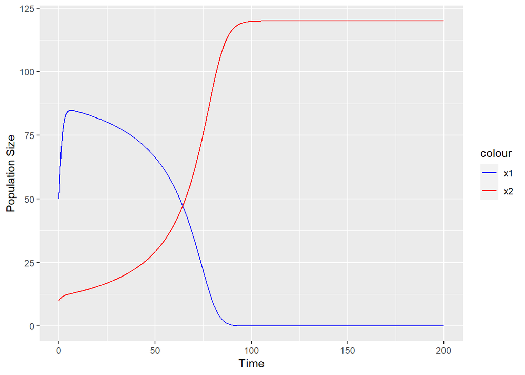

```r
simulate_LV(r1 = 1.0, r2 = 0.3,
            a12 = 1.2, a21 = 1.2,
            K1 = 100, K2 = 120,
            x1 = 50, x2 = 10,
            tmax=200)
```

- Haga una interpretación biológica de cada uno de los parámetros del modelo.
- Describa qué es lo que representan los diferentes términos de las ecuaciones diferenciales.

- Considere un caso en el cual una de las poblaciones se extingue (por ejemplo $x_2$) y analice el comportamiento asintótico (en el límite cuando $t\to \infty$) de la otra. Cuál es el tamaño de la población en condiciones estacionarias $\lim_{t\to\infty} x_1(t)=:\bar{x}_1$? Analice cómo se afecta el valor de $\bar{x}_1$ con cada uno de los parámetros. Para esto, haga simulaciones con valores iniciales $x_1^0>\bar{x}_1$ y también $x_1^0<\bar{x}_1$.

### Caso en el que $x_2$ se extingue:

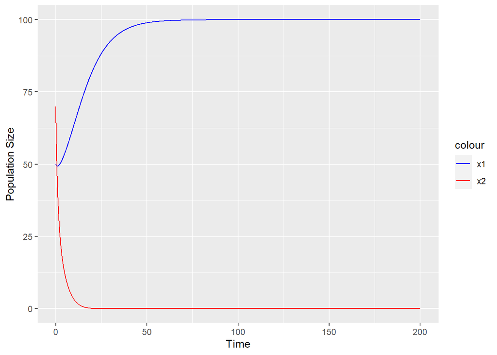

```r
simulate_LV(r1 = 0.1, r2 = 0.4,
            a12 = 1.2, a21 = 1.3,
            K1 = 100, K2 = 50,
            x1 = 50, x2 = 70,
            tmax=200)
```

El valor estacionario $\bar{x}_1=100$ corresponde con el valor de capacidad de carga de la población $x_1$, es decir $K_1=100$.

### Simulación con $x_1^0 > \bar{x}_1$, $x_1^0=120$:

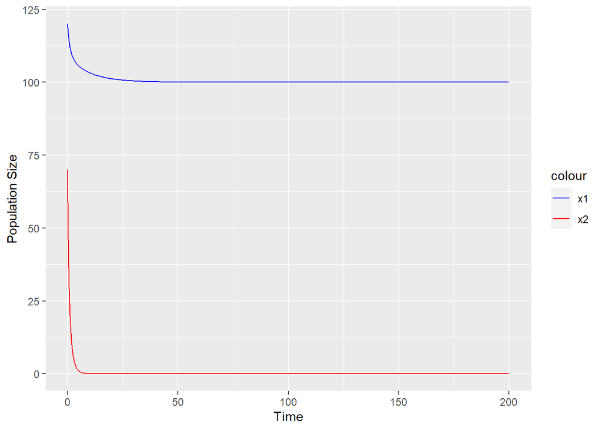

```r
simulate_LV(r1 = 0.1, r2 = 0.4,
            a12 = 1.2, a21 = 1.3,
            K1 = 100, K2 = 50,
            x1 = 120, x2 = 70,
            tmax=200)
```

### Simulación con $x_1^0 < \bar{x}_1$, $x_1^0=80$:

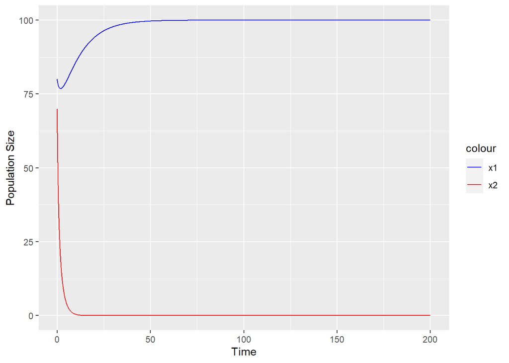

```r
simulate_LV(r1 = 0.1, r2 = 0.4,
            a12 = 1.2, a21 = 1.3,
            K1 = 100, K2 = 50,
            x1 = 80, x2 = 70,
            tmax=200)
```

Observamos que la población $x_1$ se estabiliza en el valor $\bar{x}_1=K_1$. La población $x_2$ se extingue en ambos casos.

- Ahora introduzca la segunda población. Observe que las soluciones se aproximan a valores constantes, llamados puntos de equilibrio (llámelos $\bar{x}_1$ y $\bar{x}_2$). Encuentre los puntos de equilibrio para cuatro combinaciones de los parámetros $\alpha_{12}$ y $\alpha_{21}$. Observe el efecto de estos parámetros sobre los valores estacionarios $\bar{x}_1$ y $\bar{x}_2$.

### Simulación en la que $x_2$ no se extingue:

```r
simulate_LV(r1 = 1.0, r2 = 0.3,
            a12 = -0.2, a21 = -0.2,
            K1 = 100, K2 = 120,
            x1 = 50, x2 = 10,
            tmax = 200)
```

[output not shown]

Los puntos de equilibrio son $\bar{x}_1=130$ y $\bar{x}_2=145$.

### Simulaciones con cuatro combinaciones de $\alpha_{12}$ y $\alpha_{21}$:

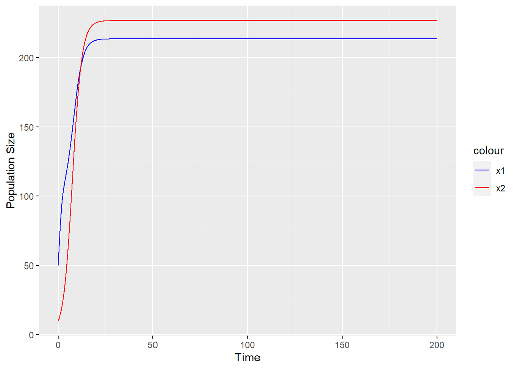

```r
simulate_LV(r1 = 1.0, r2 = 0.3,
            a12 = -0.5, a21 = -0.5,
            K1 = 100, K2 = 120,
            x1 = 50, x2 = 10,
            tmax = 200)
```

Si se incrementa la magnitud de $\alpha_{12}$ y $\alpha_{21}$ de $0.2$ a $0.5$, los valores estacionarios se incrementan.

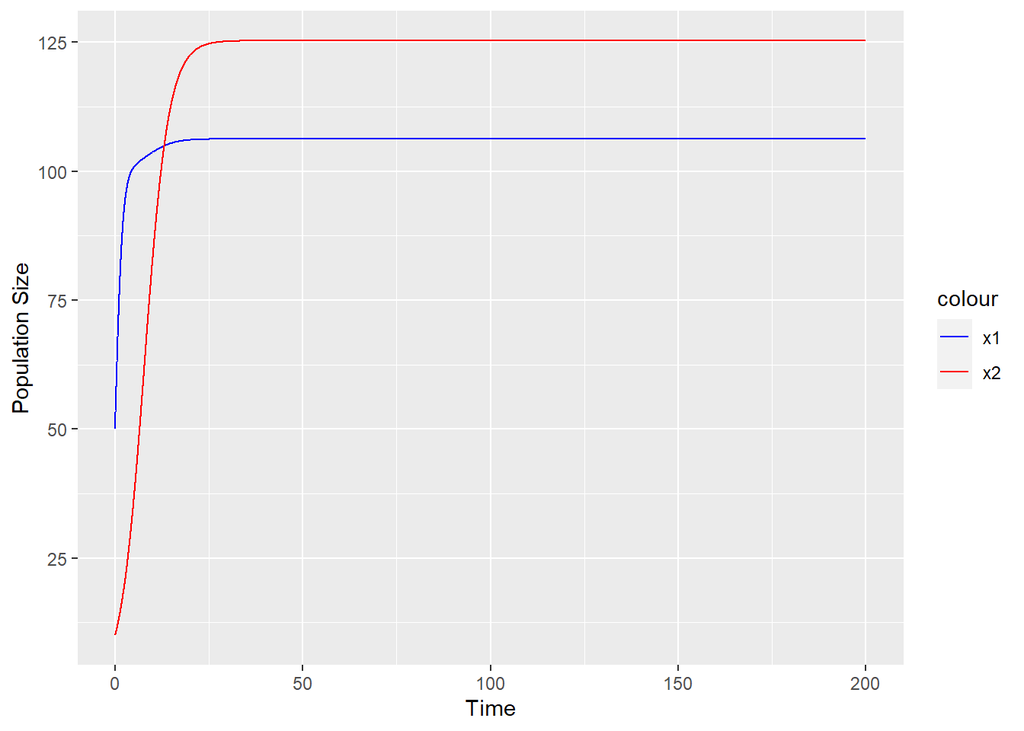

```r
simulate_LV(r1 = 1.0, r2 = 0.3,
            a12 = -0.05, a21 = -0.05,
            K1 = 100, K2 = 120,
            x1 = 50, x2 = 10,
            tmax = 200)
```

Si se disminuye la magnitud de $\alpha_{12}$ y $\alpha_{21}$ de $0.2$ a $0.05$, los valores estacionarios disminuyen.

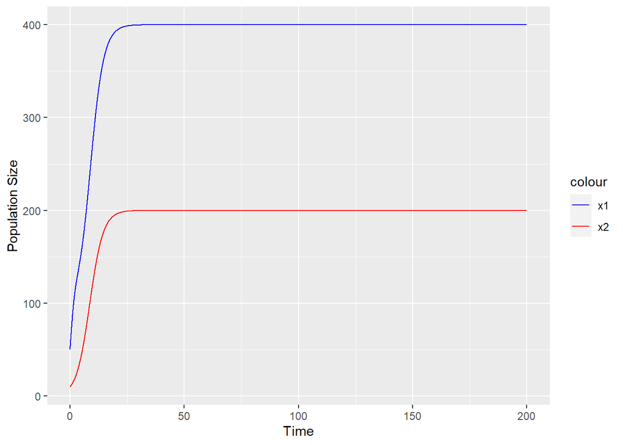

```r
simulate_LV(r1 = 1.0, r2 = 0.3,
            a12 = -1.5, a21 = -0.2,
            K1 = 100, K2 = 120,
            x1 = 50, x2 = 10,
            tmax = 200)
```

Si se incrementa la magnitud de $\alpha_{12}$ de $0.2$ a $1.5$ y $\alpha_{21}$ se mantiene igual, se observa que ambos valores estacionarios se incrementan. La diferencia entre los puntos estacionarios es: de aproximadamente $200$.

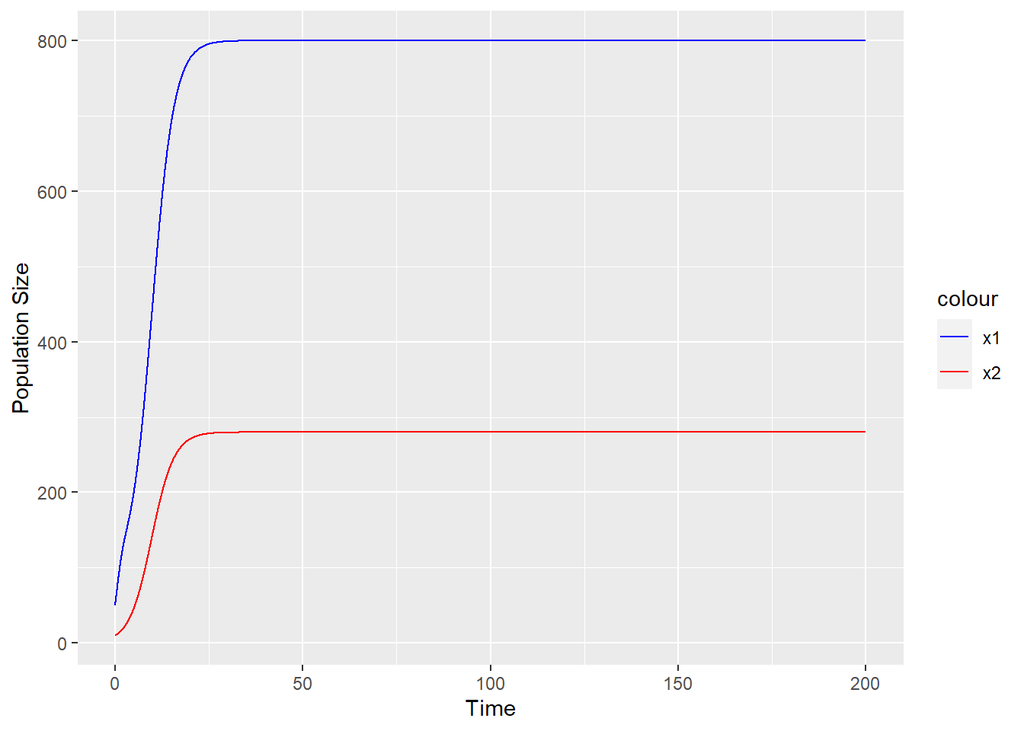

```r
simulate_LV(r1 = 1.0, r2 = 0.3,
            a12 = -2.5, a21 = -0.2,
            K1 = 100, K2 = 120,
            x1 = 50, x2 = 10,
            tmax = 200)
```

Si se incrementa la magnitud de $\alpha_{12}$ de $0.2$ a $2.5$ y $\alpha_{21}$ se mantiene igual, se observa que ambos valores estacionarios se incrementan aún más. Pero esta vez, la diferencia entre los puntos estacionarios es aún mayor: de poco más de $500$.

- A continuación, evalúe el efecto de los parámetros $r_1$ y $r_2$ sobre la respuesta del modelo.

### Simulaciones con diferentes valores de $r_1$ y $r_2$:

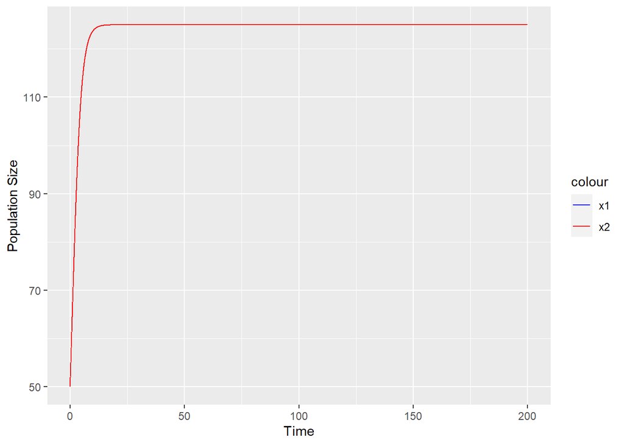

```r
simulate_LV(r1 = 0.5, r2 = 0.5,
            a12 = -0.2, a21 = -0.2,
            K1 = 100, K2 = 100,
            x1 = 50, x2 = 50,
            tmax = 200)
```

Se incrementará $r_1$ y se dejará fijo a $r_2$:

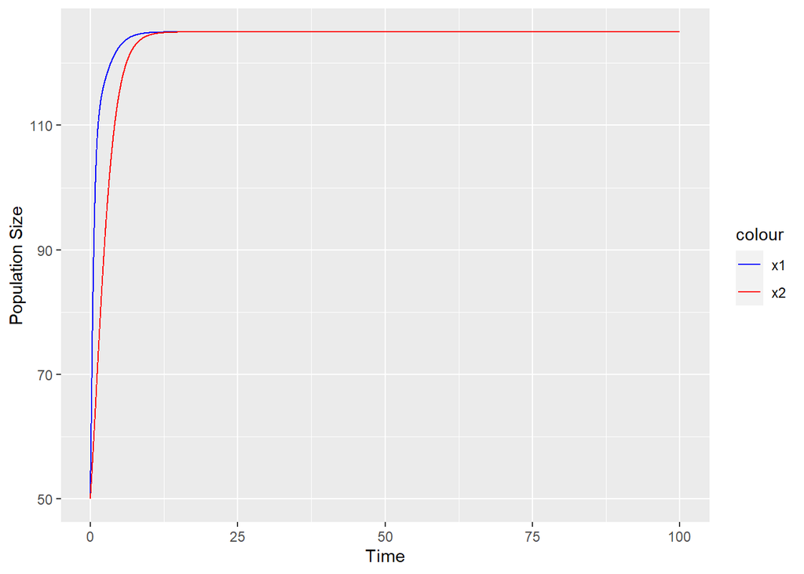

```r
simulate_LV(r1 = 2.5, r2 = 0.5,
            a12 = -0.2, a21 = -0.2,
            K1 = 100, K2 = 100,
            x1 = 50, x2 = 50,
            tmax = 100)
```

Observamos que la población $x_1$ alcanza más rápidamente el punto estacionario.

Ahora, haremos a $r_2$ más pequeño.

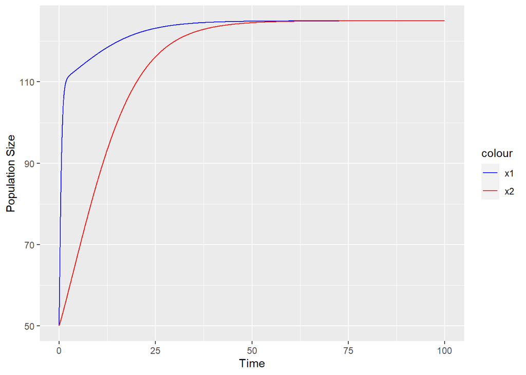

```r
simulate_LV(r1 = 2.5, r2 = 0.1,
            a12 = -0.2, a21 = -0.2,
            K1 = 100, K2 = 100,
            x1 = 50, x2 = 50,
            tmax = 100)
```

Si además se hace a $r_2$ más pequeño, vemos que la diferencia del tiempo que les toma a ambas poblaciones llegar al punto estacionario, es aún mayor, llegando a ser poco más de $50$ unidades de tiempo.

- Analice la estabilidad de los puntos de equilibrio; para ello suponga varias condiciones iniciales ligeramente diferentes del punto de equilibrio (por encima y por debajo de los valores de equilibrio) y observe el comportamiento de las soluciones. El equilibrio es estable (en realidad, *asintóticamente estable*) si las soluciones ligeramente diferentes del equilibrio resultan en trayectorias que “regresan” a éste. En caso contrario es inestable.

### Analizando la estabilidad de los puntos de equilibrio:

Se escogerá la simulación para la que $\bar{x}_1=130$ y $\bar{x}_2=145$.

```r
simulate_LV(r1 = 1.0, r2 = 0.3,
            a12 = -0.2, a21 = -0.2,
            K1 = 100, K2 = 120,
            x1 = 50, x2 = 10,
            tmax = 200)
```

[output not shown]

Caso en el que $x_1^0>\bar{x}_1$ y $x_2^0>\bar{x}_2$:

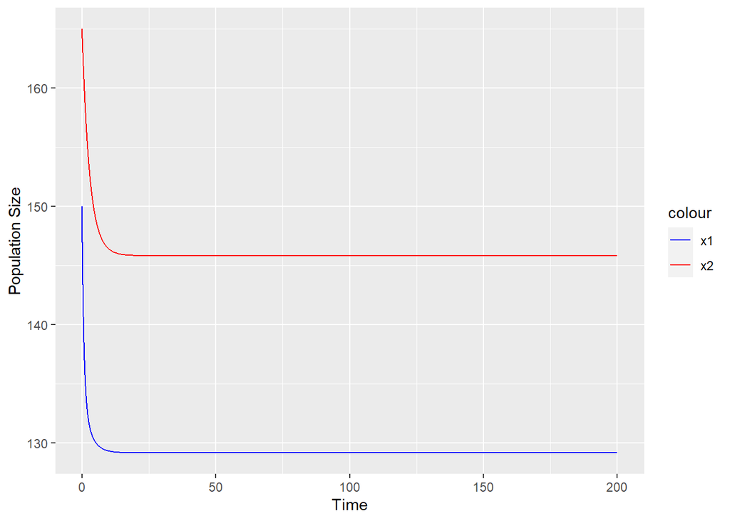

```r
simulate_LV(r1 = 1.0, r2 = 0.3,
            a12 = -0.2, a21 = -0.2,
            K1 = 100, K2 = 120,
            x1 = 150, x2 = 165,
            tmax = 200)
```

Observamos que las trayectorias regresan a los puntos de equilibrio. Es decir, son puntos de equilibrio estables.

Ahora intentamos con $x_1^0<\bar{x}_1$ y $x_2^0<\bar{x}_2$:

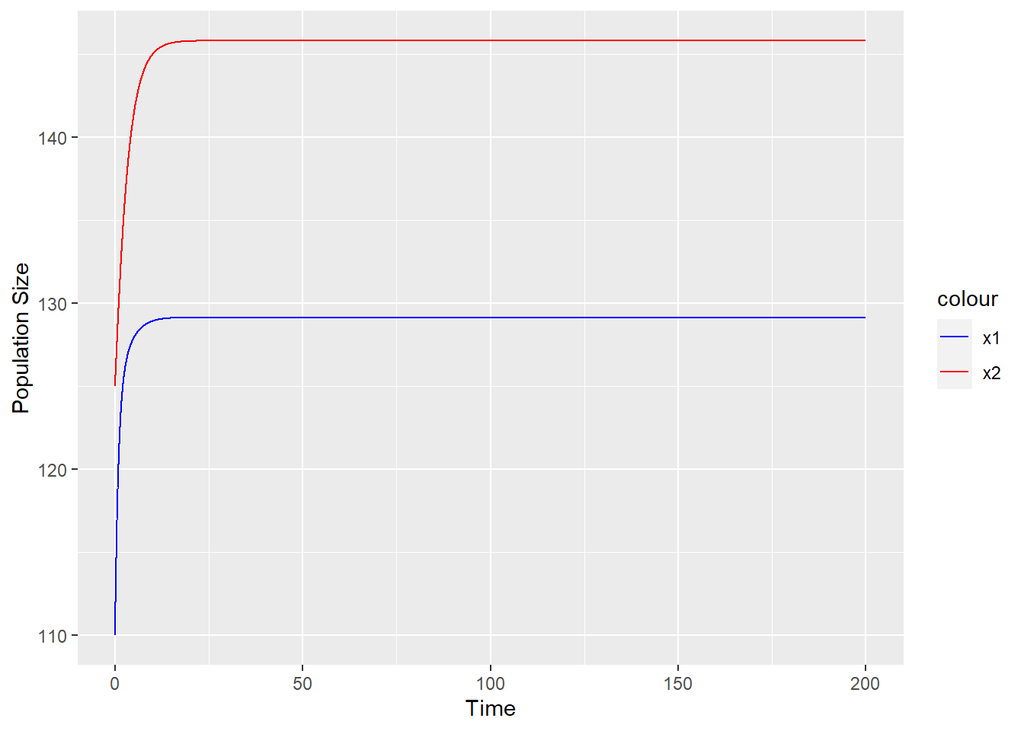

```r
simulate_LV(r1 = 1.0, r2 = 0.3,
            a12 = -0.2, a21 = -0.2,
            K1 = 100, K2 = 120,
            x1 = 110, x2 = 125,
            tmax = 200)
```

Observamos que las trayectorias regresan a los puntos de equilibrio. Es decir, seguimos confirmando que los puntos de equilibrio son estables.

## 2. Modelos de tiempo discreto

En este problema consideramos un modelo de interacción Huesped-Parasitoide, usada con frecuencia en control biológico. Se trata de un modelo de la forma
$$\begin{align*}
N_{t+1} & = \frac{\lambda N_t e^{−a P_t}}{1 + d N_t}\\
P_{t+1} &= c N_t(1 − e^{−a Pt})
\end{align*}$$

Este modelo **Huesped - Parasitoide**, es conocido como Nicholson-Bailey Modificado, para el cual hemos definido

- $N_t$: Densidad (número) de huéspedes
- $P_t$: Densidad (número) de parásitos
- $\lambda$: Tasa de reproducción del huésped
- $a$: Área donde el parasitoide busca huéspedes.
- $c$: No. promedio de huevos viables en un huésped
- $d$: Capacidad de carga del ecosistema para huéspedes

```r
library(deSolve)
library(ggplot2)

# Nicholson-Bailey
simulate_NB <- function(L, a, c, d, N, P, tmax) {
  params <- c(L=L, a=a, c=c, d=d, N=N, P=P)
  state <- c(N=N, P=P)

  NB <- function(t, state, params) {
    with(as.list(c(state, params)), {
      N = (L * N * exp(-a * P)) # / (1 + d * N)
      P = c * N * (1 - exp(-a * P))
      list(c(N, P))
    })
  }

  times <- seq(0, tmax, by=0.01)

  out <- as.data.frame(ode(y = state, times=times, func=NB, parms=params, method="iteration"))

  ggplot(out, aes(x = time)) +
      geom_line(aes(y = N, color = "N")) +
      geom_line(aes(y = P, color = "P")) +
      xlab("Time") +
      ylab("Population Size") +
      scale_color_manual(values = c("N" = "aquamarine3", "P" = "chocolate2"))

}
```

- Simule las respuestas y haga una interpretación biológica del modelo y de sus resultados.

### Simulación e interpretación biológica del modelo:

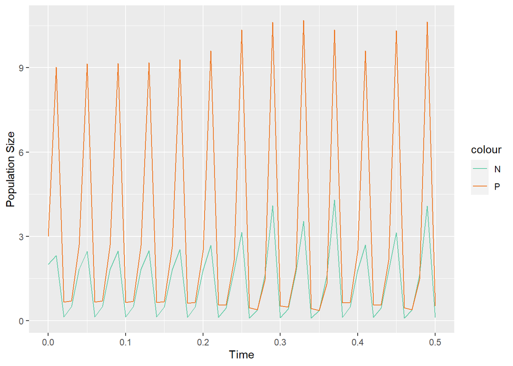

```r
simulate_NB(L=5.2, a=0.5, c=5.0, d=0.5, N=2, P=3, tmax=0.5)
```

$\lambda$ es la tasa de crecimiento del huesped. $a$ es la tasa de parasitismo: tasa a la que el parásito ataca e infecta el huesped. $c$ es la eficiencia del parasitismo: tasa a la que el parásito aprovecha satisfactoriamente el huesped por su propia reproducción. $d$ representa el impacto de la densidad de la población huesped en su propio crecimiento y puede capturar factores como la limitación de recursos, la competencia o las interacciones intraespecíficas dentro de la población huesped

Evalúe el efecto de cada uno de los parámetros sobre el equilibrio.

### Evaluando el efecto de cada parámetro sobre el equilibrio:

#### Tasa de crecimiento $\lambda$ mayor a la tasa de eficiencia $c$:

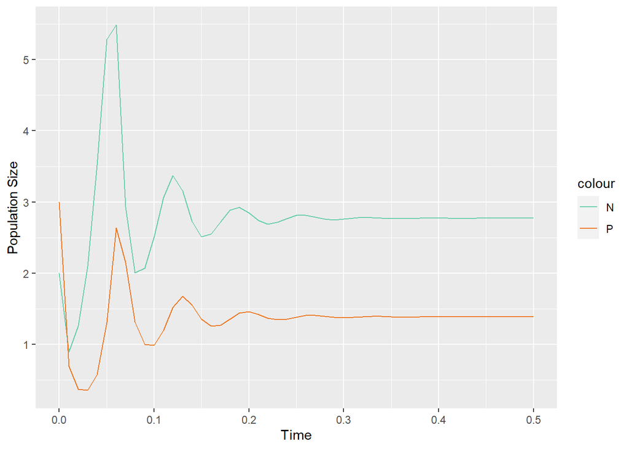

```r
simulate_NB(L=2.0, a=0.5, c=1.0, d=0.5, N=2, P=3, tmax=0.5)
```

#### Tasa de crecimiento $\lambda$ menor a la tasa de eficiencia $c$:

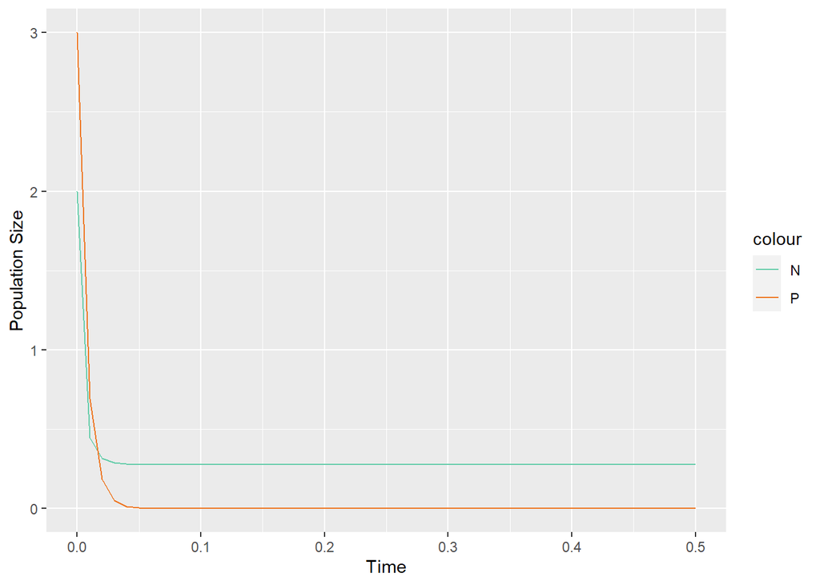

```r
simulate_NB(L=1.0, a=0.5, c=2.0, d=0.5, N=2, P=3, tmax=0.5)
```

#### Tasa de crecimiento $\lambda$ y tasa de eficiencia $c$ con el mismo valor:

```r
simulate_NB(L=2.0, a=0.5, c=2.0, d=0.5, N=2, P=3, tmax=0.5)
```

[output not shown]

#### Variando los valores de la tasa de parasitismo $a$:

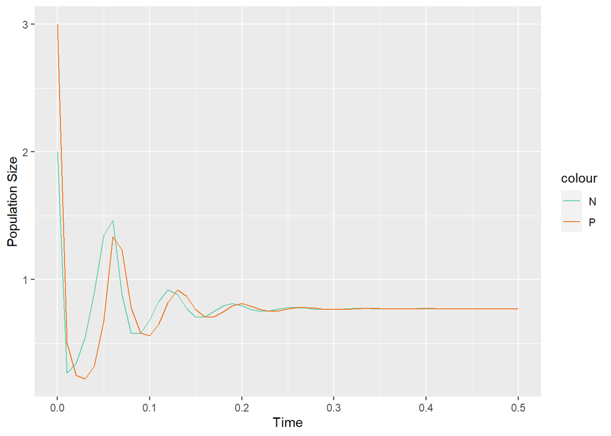

```r
simulate_NB(L=2.0, a=0.9, c=2.0, d=0.5, N=2, P=3, tmax=0.5)
```

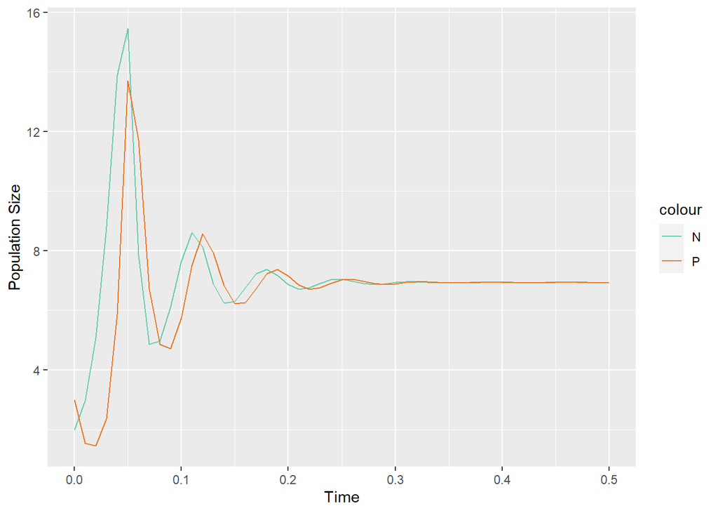

```r
simulate_NB(L=2.0, a=0.1, c=2.0, d=0.5, N=2, P=3, tmax=0.5)
```

Una menor tasa de parasitismo parece incrementar los puntos de equilibrio.

#### Variando los valores de la dependencia de densidad $d$:

```r
simulate_NB(L=2.0, a=0.5, c=2.0, d=0.1, N=2, P=3, tmax=0.5)
```

[output not shown]

```r
simulate_NB(L=2.0, a=0.5, c=2.0, d=0.9, N=2, P=3, tmax=0.5)
```

[output not shown]

* Haga una interpretación biológica de cada uno de los parámetros incluidos en el modelo.

## Interpretación biológica de los parámetros

- Para dos de los casos cuyos parámetros se muestran en la siguiente tabla,

| $a$ | $\lambda$ | $c$ | $d$ | $N_0$ | $P_0$ |
| --- | --- | --- | --- | --- | --- |
| 0.5 | 9.6 | 2.5 | 2.7 | 1.06 | 2.04 |
| 0.4 | 8.7 | 5.5 | 4.7 | 0.27 | 2.04 |
| 0.4 | 8.8 | 4.5 | 4.8 | 0.28 | 2.09 |
| 0.4 | 8.2 | 3.9 | 2.9 | 0.40 | 2.09 |
| 0.068 | 2.0 | 2.35 | 50 | 25.0 | 5.00 |

- Haga una simulación, con las condiciones iniciales dadas en la tabla.
- Describa el comportamiento dinámico de las poblaciones
- Analice el punto de equilibrio y su estabilidad

### Simulaciones con los valores de la tabla:

#### Usando los valores de la fila 2:

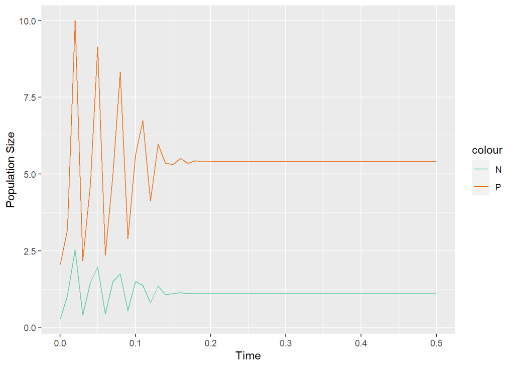

```r
simulate_NB(L=8.7, a=0.4, c=5.5, d=4.7, N=0.27, P=2.04, tmax=0.5)
```

#### Tomando valores iniciales para $N$ y $P$ ligeramente mayores:

El equilibrio se alcanza antes, sin embargo siguen siendo los mismos, es decir que se puede decir que es estable.

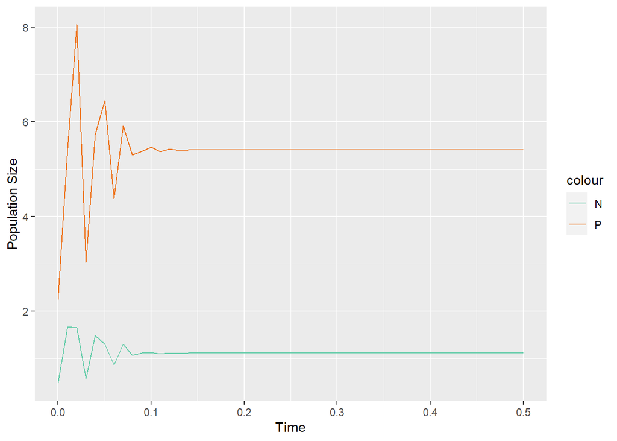

```r
simulate_NB(L=8.7, a=0.4, c=5.5, d=4.7, N=0.47, P=2.24, tmax=0.5)
```

### Usando los valores de la fila 5:

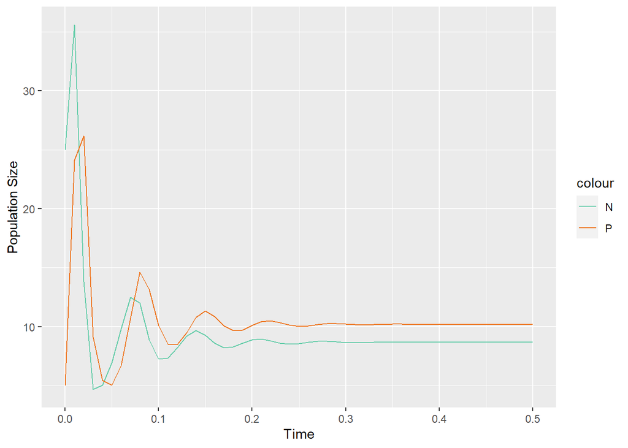

```r
simulate_NB(L=2.0, a=0.068, c=2.35, d=50, N=25, P=5, tmax=0.5)
```

#### Tomando valores iniciales para $N$ y $P$ ligeramente menores:

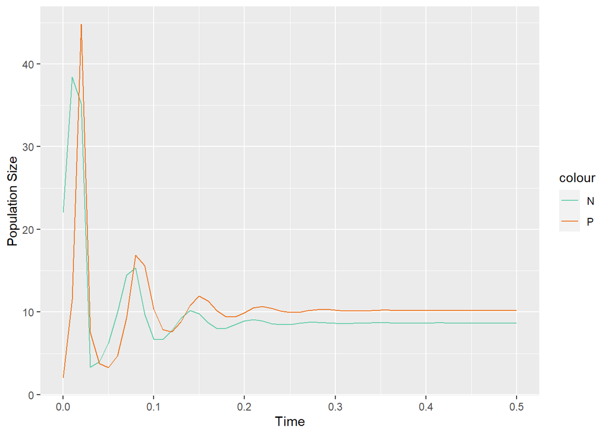

```r
simulate_NB(L=2.0, a=0.068, c=2.35, d=50, N=22, P=2, tmax=0.5)
```

El equilibrio se alcanza después, sin embargo siguen siendo los mismos, es decir que se puede decir que es estable.

- Considere otras condiciones iniciales y observe si la dinámica sufre modificaciones

### Variando las condiciones iniciales $N$ y $P$:

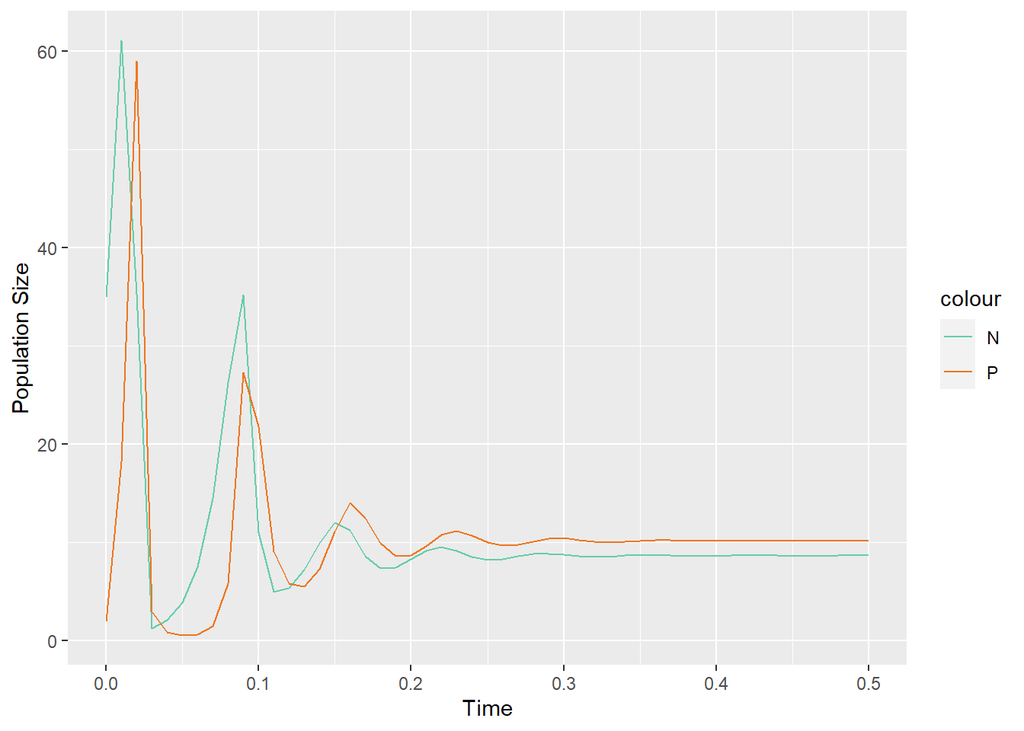

```r
simulate_NB(L=2.0, a=0.068, c=2.35, d=50, N=35, P=2, tmax=0.5)
```

Al cambiar ligeramente los valores de las condiciones iniciales, la dinámica sufre algunas modificaciones pero se alcanzan los mismos puntos de equilibrio.

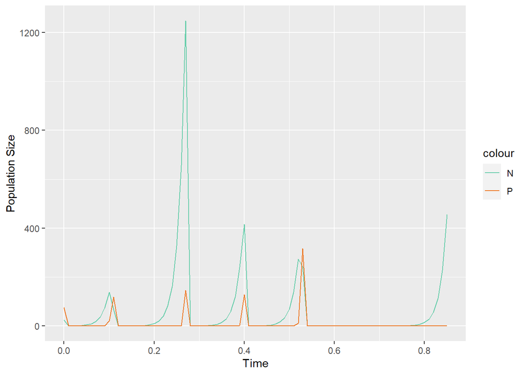

```r
simulate_NB(L=2.0, a=0.068, c=2.35, d=50, N=25, P=75, tmax=0.85)
```

- Escoja dos de los parámetros del modelo y haga variaciones de $\pm 10$ % en cada uno por separado y observe cómo se modifica el comportamiento o los valores de equilibrio.

### Variando los parámetros $\lambda$ y $c$ $\pm 10$ %:

#### Modelo sin variación:

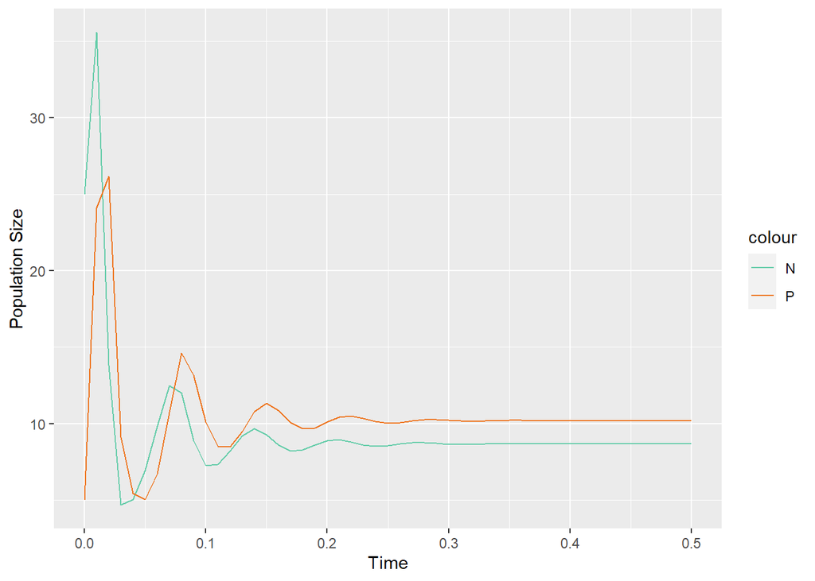

```r
simulate_NB(L=2.0, a=0.068, c=2.35, d=50, N=25, P=5, tmax=0.5)
```

#### Incrementando $\lambda$ un $10$%:

El equilibrio aumenta ligeramente para el huesped.

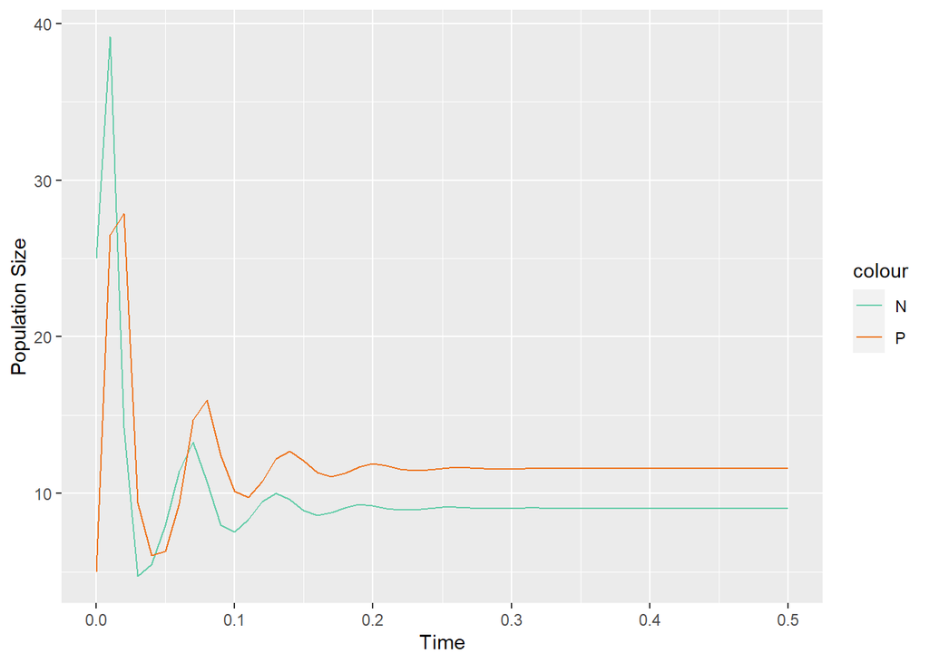

```r
simulate_NB(L=2.2, a=0.068, c=2.35, d=50, N=25, P=5, tmax=0.5)
```

#### Incrementando $c$ un $10$%:

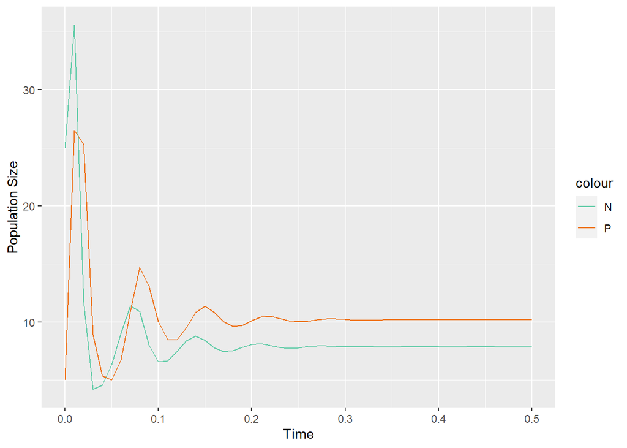

```r
simulate_NB(L=2.0, a=0.068, c=2.585, d=50, N=25, P=5, tmax=0.5)
```

#### Disminuyendo $\lambda$ un $10$%:

El equilibrio disminuye ligeramente para el huesped.

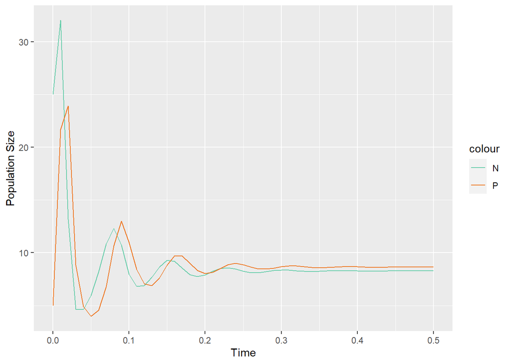

```r
simulate_NB(L=1.8, a=0.068, c=2.35, d=50, N=25, P=5, tmax=0.5)
```

#### Disminuyendo $c$ un $10$%:

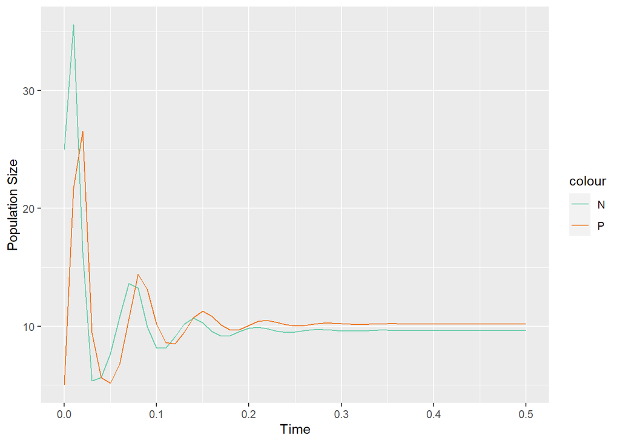

```r
simulate_NB(L=2.0, a=0.068, c=2.115, d=50, N=25, P=5, tmax=0.5)
```

## 3. Modelo de epidemia

Por último, vamos a usar un modelo de epidemia (el mismo SIR que vimos en clase) para estudiar algunos aspectos simples asociados con un brote. El modelo usado es (despreciando tiempo de incubación):

$$\begin{align*}
\frac{d S(t)}{dt}&= -\beta\, S\, I\\
\frac{d I(t)}{dt}&= \beta\, S\, I-\gamma\,I\\
\frac{d R(t)}{dt}&= \gamma\,I
\end{align*}$$

donde $\gamma=1/T$ siendo $T$ el número promedio de días que una persona es contagiosa. $\beta$ se calcula a partir de un parámetro llamado *número básico de reproducción*: $\beta = R_0/T$. Para efectos de la simulación, es mejor usar valores de proporción de la población; por lo tanto, recomiendo usar como valores iniciales esos números. Suponga que la población es de un millón de personas y el brote comienza con una sola contagiada ($I(0) = 1/1000000$ es la fracción). Todos los demás ($S(0) = 999999/1000000$ es la fracción) son suceptibles y $R(0)=0$.

- Escoja un valor de $R_0\in [1,1.4]$ y calcule el valor de $\beta$ correspondiente. Seleccione también un valor para $T\in[1,5]$ y uno para la letalidad (caracterizada por el IFR —Infection Fatality Ratio— que es la fracción de los infectados que mueren por causa de la enfermedad). Escoja para este valor un número entre 0.010 y 0.025.

### Implementación del modelo SIR:

```r
library(deSolve)
library(ggplot2)

# Modelo SIR
simulate_SIR <- function(R0, T, S, I, R, F, IFR, tmax) {

  B <- R0 / T
  G <- 1.0 / T

  params <- c(B=B, G=G, IFR=IFR)
  state <- c(S=S, I=I, R=R, F=F, RF=R+F) # recuperados y fatalidades iniciales son cero

  SIR <- function(t, state, params) {
    with(as.list(c(state, params)), {
      dS = -B * S * I
      dI = B * S * I - G * I
      dR = G * I * (1.0 - IFR) # recuperados
      dF = G * I * IFR # fatalidades
      dRF = dR + dF # recuperados + fatalidades combinados
      list(c(dS, dI, dR, dF, dRF))
    })
  }

  times <- seq(0, tmax, by=0.01)

  out <- as.data.frame(ode(y = state, times=times, func=SIR, parms=params))

  fatalities <- tail(out, 1)
  print(fatalities)

  ggplot(out, aes(x = time)) +
      geom_line(aes(y = S, color = "Suceptibles")) +
      geom_line(aes(y = I, color = "Infectados")) +
      geom_line(aes(y = RF, color = "Recuperados + Fatalidades")) +
      geom_line(aes(y = R, color = "Recuperados")) +
      geom_line(aes(y = F, color = "Fatalidades")) +
      xlab("Time") +
      ylab("Population Size") +
      scale_color_manual(values = c("Suceptibles" = "turquoise2", "Infectados" = "orangered", "Recuperados"="green3", "Fatalidades"="royalblue", "Recuperados + Fatalidades"="gray53"))


}
```

- Simule la dinámica del brote y determine el pico máximo de infectados y el momento cuando este se produce.
- ¿Cuál es el número de muertos como resultado del brote? (Puede ayudar usar el comando `tail(out,1)` en el *script* que ya usamos).

### Simulación con parámetros sugeridos;

```r
simulate_SIR(R0=2.0, T=3.0, S=999999/1000000, I=1.0/1000000, R=0.0, F=0.0, IFR=0.025, tmax=100)
```

```
##       time       S            I         R          F        RF
## 10001  100 0.20319 3.649417e-06 0.7768862 0.01992016 0.7968063
```

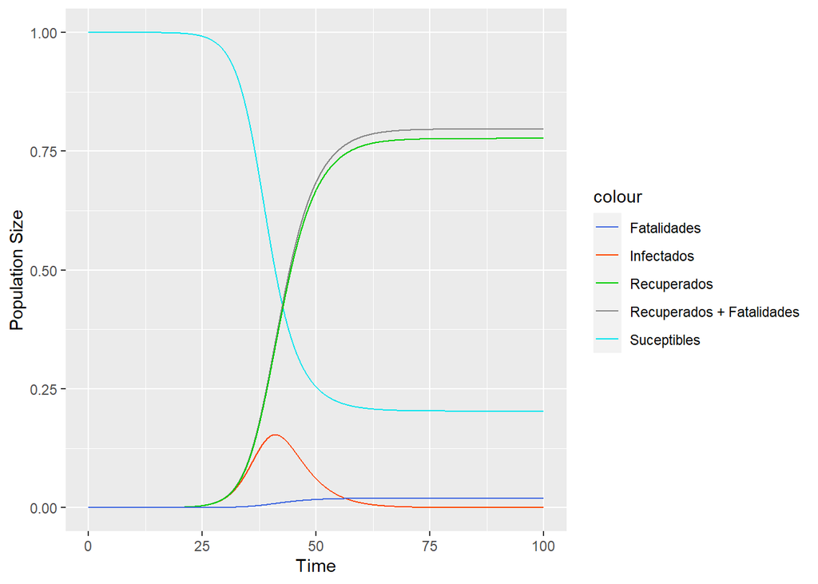

El pico sobrepasa las 0.125 unidades de población y se presenta aproximadamente a las 40 unidades de tiempo.

Al usar la función `tail(out, 1)` podemos ver que el número de fatalidades acumuladas es de $0.01992016$ unidades de población cuando se usa un $IFR$ de $0.025$.

- ¿Qué es más grave, desde el punto de vista de los muertos totales, una versión diferente de la enfermedad que es 40% más transmisible o una que es 40% más letal? Y, desde el punto de vista del pico de la epidemia?

### Simulación con $40$% más transmisibilidad:

```r
simulate_SIR(R0=2.8, T=3.0, S=999999/1000000, I=1.0/1000000, R=0.0, F=0.0, IFR=0.025, tmax=100)
```

```
##       time          S           I         R          F        RF
## 10001  100 0.07502527 1.30182e-09 0.9018504 0.02312437 0.9249747
```

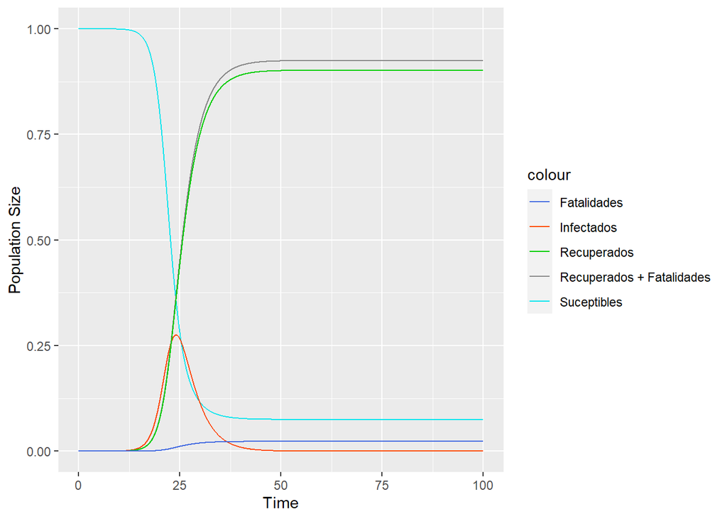

El pico se alcanza antes de las 25 unidades de tiempo y sobrepasa las 0.25 unidades de población.

El número de fatalidades acumuladas alcanza las $0.02312437$ unidades de población.

### Simulación con $40$% más letalidad:

```r
simulate_SIR(R0=2.0, T=3.0, S=999999/1000000, I=1.0/1000000, R=0.0, F=0.0, IFR=0.035, tmax=100)
```

```
##       time       S            I         R          F        RF
## 10001  100 0.20319 3.649417e-06 0.7689181 0.02788822 0.7968063
```

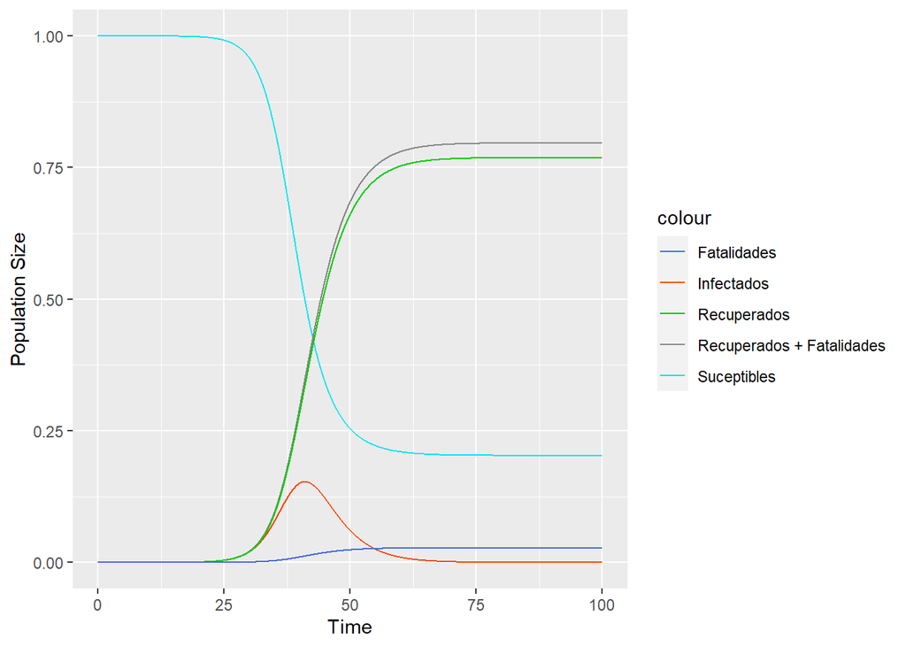

Aumentar la letalidad no parece incidir significativamente en cuándo se alcanza el pico ni la cantidad de infectados.

El número de fatalidades si se incrementa significativamente y alcanza $0.02788822$ unidades de población.

- Usted, ¿qué considera que sería necesario agregarle al modelo para tener en cuenta el período de incubación durante el cual una persona infectada no es infecciosa (generalmente se le llama a este estado *Expuesto*)?